# FEC Analysis

Cooper

02/14/2023

## 1 Introduction, Variables, and Analysis

In this analysis, we focus on the fear of falling in GAPCare I dataset. The variables used to measure the fear of falling come from falls efficacy scale file. There are seen variables we need to consider. They are dressed or undressed, Taking a bath or shower, Getting in or out of a chair, Going up or down stairs, Reaching for something above your head or on the ground, Walking up or down a slope, and Going out to a social event. We consider the seven varaibles seperately in control group and intervention group. We will calculate the rates each of the seven variables and the completenesses of each seven variables in each group. Finally, we drew a plot for the seven rates of the two groups.

## 2 R Code

```r
# Import Packages will be usedin this study
# For Different Tables and Figures
library(dplyr)

# Impoort data set
setwd('/Users/dhyscuduke/Desktop')
DATA = read.csv('/Users/dhyscuduke/Desktop/GAPcareI_R03_DATA_2022-10-21_1144_deidentified.csv')

# Create the two 55 patients groups based on intervention
Control_data <- DATA %>% filter(intervention_random == "0")
Inter_data <- DATA %>% filter(intervention_random == "1")
Total_data <- rbind(Control_data, Inter_data)

#ID of Usual care, Intervention, and together
id_Control <- Control_data$record_id
id_Inter <- Inter_data$record_id
id_Total <- Total_data$record_id

#Filter all data based on times in usual care, intervention, and together
Control_data_com <- DATA %>% filter(record_id %in% Control_data$record_id)
Inter_data_com <- DATA %>% filter(record_id %in% Inter_data$record_id)
Total_Data <- DATA %>% filter(record_id %in% id_Total)

Control_data_com$d180_fes1[which(Control_data_com$d180_fes1==99)] <- NA
Control_data_com$d180_fes2[which(Control_data_com$d180_fes2==99)] <- NA
Control_data_com$d180_fes3[which(Control_data_com$d180_fes3==99)] <- NA
Control_data_com$d180_fes4[which(Control_data_com$d180_fes4==99)] <- NA
Control_data_com$d180_fes5[which(Control_data_com$d180_fes5==99)] <- NA
Control_data_com$d180_fes6[which(Control_data_com$d180_fes6==99)] <- NA
Control_data_com$d180_fes7[which(Control_data_com$d180_fes7==99)] <- NA

Inter_data_com$d180_fes1[which(Inter_data_com$d180_fes1==99)] <- NA
Inter_data_com$d180_fes2[which(Inter_data_com$d180_fes2==99)] <- NA
Inter_data_com$d180_fes3[which(Inter_data_com$d180_fes3==99)] <- NA
Inter_data_com$d180_fes4[which(Inter_data_com$d180_fes4==99)] <- NA
Inter_data_com$d180_fes5[which(Inter_data_com$d180_fes5==99)] <- NA
Inter_data_com$d180_fes6[which(Inter_data_com$d180_fes6==99)] <- NA
Inter_data_com$d180_fes7[which(Inter_data_com$d180_fes7==99)] <- NA

#Complete of FEC in control group
length(na.omit(Control_data_com$d180_fes1))/55
```

```
## [1] 0.6545455
```

```r
length(na.omit(Control_data_com$d180_fes2))/55
```

```
## [1] 0.6363636
```

```r
length(na.omit(Control_data_com$d180_fes3))/55
```

```
## [1] 0.6545455
```

```r
length(na.omit(Control_data_com$d180_fes4))/55
```

```
## [1] 0.6363636
```

```r
length(na.omit(Control_data_com$d180_fes5))/55
```

```
## [1] 0.6181818
```

```r
length(na.omit(Control_data_com$d180_fes6))/55
```

```
## [1] 0.6181818
```

```r
length(na.omit(Control_data_com$d180_fes7))/55
```

```
## [1] 0.6
```

```r
#Complete of FEC in intervention group
length(na.omit(Inter_data_com$d180_fes1))/55
```

```
## [1] 0.7454545
```

```r
length(na.omit(Inter_data_com$d180_fes2))/55
```

```
## [1] 0.7454545
```

```r
length(na.omit(Inter_data_com$d180_fes3))/55
```

```
## [1] 0.7454545
```

```r
length(na.omit(Inter_data_com$d180_fes4))/55
```

```
## [1] 0.7454545
```

```r
length(na.omit(Inter_data_com$d180_fes5))/55
```

```
## [1] 0.7454545
```

```r
length(na.omit(Inter_data_com$d180_fes6))/55
```

```
## [1] 0.7272727
```

```r
length(na.omit(Inter_data_com$d180_fes7))/55
```

```
## [1] 0.7454545
```

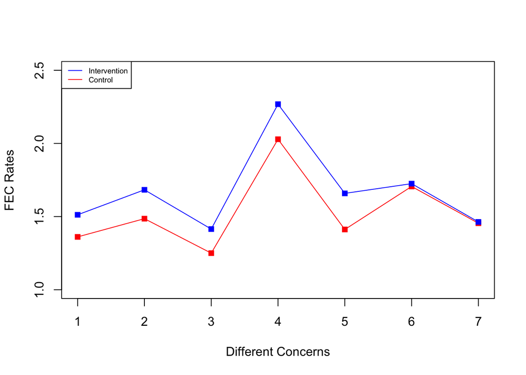

```r
#Average rates of FEC in each group with different events
a1<-sum(na.omit(Control_data_com$d180_fes1))/length(na.omit(Control_data_com$d180_fes1))
a2<-sum(na.omit(Control_data_com$d180_fes2))/length(na.omit(Control_data_com$d180_fes2))
a3<-sum(na.omit(Control_data_com$d180_fes3))/length(na.omit(Control_data_com$d180_fes3))
a4<-sum(na.omit(Control_data_com$d180_fes4))/length(na.omit(Control_data_com$d180_fes4))
a5<-sum(na.omit(Control_data_com$d180_fes5))/length(na.omit(Control_data_com$d180_fes5))
a6<-sum(na.omit(Control_data_com$d180_fes6))/length(na.omit(Control_data_com$d180_fes6))
a7<-sum(na.omit(Control_data_com$d180_fes7))/length(na.omit(Control_data_com$d180_fes7))
b1<-sum(na.omit(Inter_data_com$d180_fes1))/length(na.omit(Inter_data_com$d180_fes1))
b2<-sum(na.omit(Inter_data_com$d180_fes2))/length(na.omit(Inter_data_com$d180_fes2))
b3<-sum(na.omit(Inter_data_com$d180_fes3))/length(na.omit(Inter_data_com$d180_fes3))
b4<-sum(na.omit(Inter_data_com$d180_fes4))/length(na.omit(Inter_data_com$d180_fes4))
b5<-sum(na.omit(Inter_data_com$d180_fes5))/length(na.omit(Inter_data_com$d180_fes5))
b6<-sum(na.omit(Inter_data_com$d180_fes6))/length(na.omit(Inter_data_com$d180_fes6))
b7<-sum(na.omit(Inter_data_com$d180_fes7))/length(na.omit(Inter_data_com$d180_fes7))

#Total average rates
Total_Con <- a1+a2+a3+a4+a5+a6+a7
Total_Inter <- b1+b2+b3+b4+b5+b6+b7

#Plots to compare rates between control and intervention
X <- c(1,2,3,4,5,6,7)
Y1 <- c(a1,a2,a3,a4,a5,a6,a7)
Y2 <- c(b1,b2,b3,b4,b5,b6,b7)
plot(X,Y1,col="red",cex=1,type = "o",pch=15, xlab = "Different Concerns", ylab = "FEC Rates",ylim = c(1, 2.5))
lines(X,Y2,col="blue",cex=1,type = "o",pch=15)
legend("topleft",cex=.6,c("Intervention","Control"),col=c("Blue","Red"),lty=1:1)
```

## 3 Outcomes

Dressed or Undressed

| Completeness in Control | Completeness in Intervention | Rates in Control | Rates in Intervention |
| --- | --- | --- | --- |
| 65.5% | 74.5% | 1.36 | 1.51 |

Taking a bath or shower

| Completeness in Control | Completeness in Intervention | Rates in Control | Rates in Intervention |
| --- | --- | --- | --- |
| 63.6% | 74.5% | 1.49 | 1.68 |

Getting in or out of a chair

| Completeness in Control | Completeness in Intervention | Rates in Control | Rates in Intervention |
| --- | --- | --- | --- |
| 65.5% | 74.5% | 1.25 | 1.41 |

Going up or down stairs

| Completeness in Control | Completeness in Intervention | Rates in Control | Rates in Intervention |
| --- | --- | --- | --- |
| 63.6% | 74.5% | 2.03 | 2.27 |

Reaching for something above your head or on the ground

| Completeness in Control | Completeness in Intervention | Rates in Control | Rates in Intervention |
| --- | --- | --- | --- |
| 61.8% | 74.5% | 1.41 | 1.66 |

Walking up or down a slope

[output not shown]

Going out to a social event

[output not shown]

## 4 Summary

The rates of fear for falling are higher in intervention group. Patients in the intervention group should pay more attention to the problem of falling so that they are more worried about the consequences of falling when they do certain actions. That’s why they’re more afraid of falling.